# R Seminar Week 4 – For Loops

John Kearns

2023-11-03

General context: We are trying to visualize employment data for some areas in NJ for the years 2016 to 2023

The following links will be helpful: “https://data.bls.gov/cew/doc/titles/industry/industry_titles.csv” “https://data.bls.gov/cew/doc/titles/area/area_titles.csv” “https://www.bls.gov/cew/classifications/ownerships/sic-ownership-titles-csv.csv” “https://data.bls.gov/cew/data/api/2023/1/area/CS408.csv” # what is “2023/1/” referring to?

```r
codes = c("US000",34001,34003,34005,34007,34009,34011,34013,34015,34017,34019,34021
,34023,34025,34027,34029,34031,34033,34035,34037,34039,34041)
```

### 2. In a new dataset, keep data that is ONLY the total covered employment for all industries. Join the information on for industry titles and area titles

```r
naics = read_csv("https://data.bls.gov/cew/doc/titles/industry/industry_titles.csv")
areas = read_csv("https://data.bls.gov/cew/doc/titles/area/area_titles.csv")
qcew_data1 = qcew_data %>%
  filter(own_code==0&industry_code=="10") %>%
  select(area_fips,industry_code,own_code,size_code,year,qtr,month1_emplvl,month2_emplvl,month3_emplvl,avg_wkly_wage) %>%
  left_join(naics) %>%
  left_join(areas)
```

### 3. Visualize average weekly wage for the US and each county in NJ on one line plot. Change the color theme of the plot and add some labels. *If time*, make Mercer County a princeton orange color, and the rest of the counties/areas black

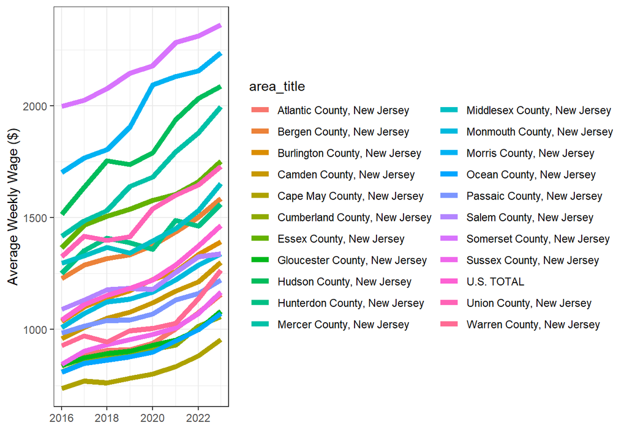

```r
ggplot(qcew_data1,aes(x=year,y=avg_wkly_wage,color=area_title)) +
  geom_line(size=2) +
  theme_bw() +
  labs(x="",y="Average Weekly Wage ($)")
```

### 4. In a new dataset, pull the following data for Mercer County: 2023 data, all industry codes less than 3 characters long and at least 100 employed persons in month 3. Make a bar chart showing the location quotients for the 5 highest and lowest industries in terms of location quotient. A location quotient is a measure of how much of the population is employed in a specific industry relative to the general population.

```r
qcew_data2 = qcew_data %>%
  filter(area_fips==34021&nchar(industry_code)<3&month3_emplvl>100&year==2023) %>%
  left_join(naics) %>%
  left_join(areas) %>%
  arrange(lq_month3_emplvl) %>%
  slice(1:5,(n()-4):n())
```

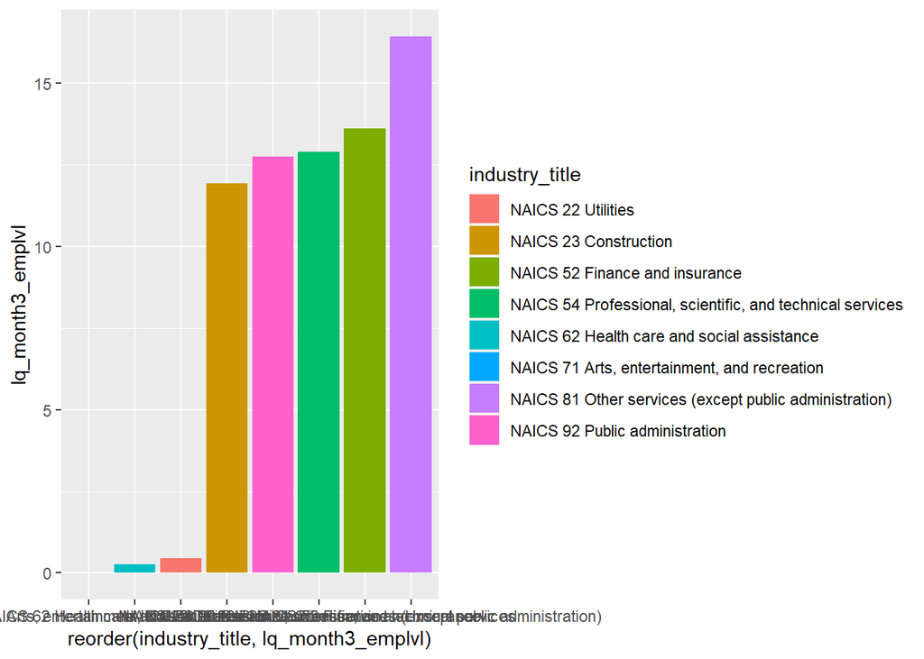

```r
ggplot(qcew_data2,aes(x=reorder(industry_title,lq_month3_emplvl),y=lq_month3_emplvl,fill=industry_title)) +
  geom_bar(stat="identity")
```

### 5. Using the all-county employment dataset, plot the change in average weekly wage in each country relative to the first year available. Save an individual plot for each county in a new pdf file. Which counties have grown the fastest and slowest?

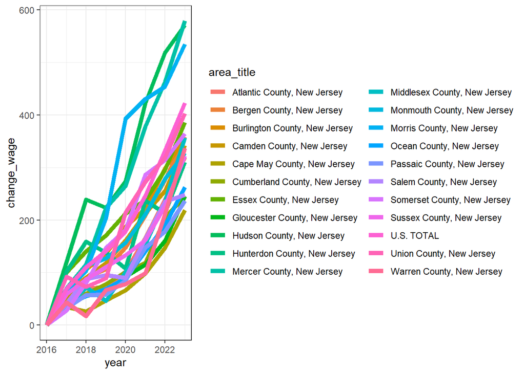

```r
qcew_data3 = qcew_data1 %>%
  group_by(area_title) %>%
  mutate(change_wage = avg_wkly_wage-avg_wkly_wage[year==2016]) %>%
  ungroup()

ggplot(qcew_data3,aes(x=year,y=change_wage,color=area_title)) +
  geom_line(size=2) +
  theme_bw()
```

```r
pdf(file="C:/Users/16094/Documents/Year 2 - Princeton/Fall 2023/R Tutoring/SPIA_R_Seminars/Week 4/Charts/county_wage_charts.pdf",height=10,width=10)
for(stat1 in unique(qcew_data3$area_title)){

plot1 = ggplot(qcew_data3 %>% filter(area_title==stat1),aes(x=year,y=change_wage)) +
  geom_line(size=2) +
  theme_bw() +
  labs(caption=stat1)

print(plot1)

}
dev.off()
```